# Submitting an array job with OSG – HTC/HPC for Stock Assessments

Authors

Nicholas Ducharme-Barth

Megumi Oshima

Last updated

2024-11-01

In this example we step through submitting an array job on OSG where we want to run the same job in a number of directories. In this case the job is running a simple R script that reads in the *data.csv* file stored in the directory, fits a linear model, and writes the parameter estimates to a *par.csv*. We specify which directories we want to run jobs in as a part of the job-array using a text file to specify the directory path names on OSG.

The *osg/array_lm* example can be set-up either by cloning the repository `git clone https://github.com/MOshima-PIFSC/NSASS-HTC-HPC-Computing.git`, or stepping through the following code:

**Coding alert!**

Note: throughout this tutorial we are using **User.Name** as a stand-in for your actual username and **project_name** as a stand-in for your project. In all cases, replace **User.Name** your actual user name and **project_name** with your specific project name.

## 1 Setup data inputs and directories

1. Define a relative path, we are starting from the root directory of this project.

```r
proj_dir = this.path::this.proj()
osg_project = "" ##TDOD Do we need this?
```

2. Define directory names for each run.

```r
dir_name = paste0("rep_0", 0:9)
```

3. Iterate across directories, create them, and then write a simple *.csv* file into them containing data to fit a linear model.

```r
for(i in seq_along(dir_name)){

    if(!file.exists(file.path(proj_dir, "example", "OSG", "array_lm", "inputs", dir_name[i], "data.csv")))
    {
        set.seed(i)
        dir.create(file.path(proj_dir, "examples", "OSG", "array_lm", "inputs", dir_name[i]), recursive=TRUE)
        tmp = data.frame(x=1:1000)
        tmp$y = (i + (0.5*i)*tmp$x) + rnorm(1000,0,i)
        write.csv(tmp, file = file.path(proj_dir, "examples", "OSG", "array_lm", "inputs", dir_name[i], "data.csv"))
    }
}
```

4. Write an R script to read in the data, run a linear model, and report back the estimated parameters.

```r
if(!file.exists(file.path(proj_dir, "examples", "OSG", "array_lm", "inputs", "run_lm_osg_array.r"))){
    script_lines = c("tmp=read.csv('data.csv')",
    "fit=lm(y~x,data=tmp)",
    "out = data.frame(par=unname(fit$coefficients))",
    "write.csv(out,file='par.csv')"
    )
    writeLines(script_lines, con = file.path(proj_dir, "examples", "OSG", "array_lm", "inputs", "run_lm_osg_array.r"))
}
```

5. Write a text file containing the full path names for where the directories will be on OSG.

```r
if(!file.exists(file.path(proj_dir, "examples", "OSG", "array_lm", "inputs", "osg_job_directories.txt"))){
    dir_lines = paste0("./../../inputs/", dir_name, "/")
    writeLines(dir_lines, con = file.path(proj_dir, "examples", "OSG", "array_lm", "inputs", "osg_job_directories.txt"))
}
```

6. In addtion to the input files, you will need to have 2 additional scripts: a wrapper script (`wrapper.sh`) and a submission script (`submission.sub`), examples of both can be found in `examples/OSG/array_lm/scripts`. To easily upload all the necessary files at once, compress the entire `array_lm/` directory as a tar.gz file `upload.array_lm.tar.gz`.

```r
system(paste0("powershell cd ", file.path(proj_dir, "examples", "OSG", "array_lm"), ";tar -czf upload.array_lm.tar.gz * "))
```

## 2 OSG workflow

1. Connect to OSG  
   As mentioned, access to OSG and file transfer is done using a pair of Terminal/PowerShell windows, we will call them *Terminal A* and *Terminal B*. In *Terminal A*, log onto your access point and create a directory for this example.

```bash
ssh User.Name@ap21.uc.osg-htc.org
mkdir array_lm
```

2. Transfer files

We will upload the compressed file`upload.array_lm.tar.gz` into the OSG directory that you just created. The following files should be included:

- all replicate data files to run the linear models on;
- the r script run_lm_osg_array.r;
- the text file osg_job_directories.txt with the directory names;
- the wrapper script wrapper.sh which unpacks files, sets up job timing, executes the R script, and packages results;
- the submission script submission.sub;
- and a bash script prep.sh that prepares the files to be run on HTCondor, including changing file permissions, making directory structures, and changing dos2unix line endings.

**Coding alert!**

In *Terminal B*, navigate to the directory where the compressed file is on your local computer and run:

```bash
scp upload.array_lm.tar.gz User.Name@ap21.uc.osg-htc.org:/home/User.Name/array_lm
```

You will be prompted for your passphrase and RSA code before the file transfers. Once the file transfer is complete, go back to *Terminal A* and you can untar the files by navigating to the `array_lm` directory and running:

```bash
tar - xvf upload.array_lm.tar.gz
```

3. Prepare scripts

Still in *Terminal A*, change the permissions and line endings for `osg_prep.sh`. Navigate to the `scripts/bash` directory and change the change the line endings for the `prep.sh` script and then execute it to prepare the other scripts as neccessary.

```bash
# navigate to directory
cd scripts/bash
# change permissions to make the file executable
chmod 777 prep.sh
# change line endings
dos2unix prep.sh
# run script
./prep.sh
```

4. Submit job

Once you are ready, you can submit the job by running the command `condor_submit`.

```bash
# navigate out of bash directory and into condor_submit directory
cd ../condor_submit
# submit job
condor_submit submission.sub
```

While your job is running, you can check on it using the following commands:

- `condor_q` shows status of all of your jobs: running, idle, or held
- `condor_q -run` shows running jobs only
- `condor_q -hold` shows jobs that are held

Using these commands you can get the job id number and peek directly at what is happening on the compute node using `condor_ssh_to_the_job <job_id>`. This is most useful for look at longer jobs or to see if intermediate files are being produced correctly.

5. Download results

Once the jobs have completed, you can retrieve the results for further analysis on your local computer. The easiest way to do this is to compress all of the directories in `array_lm/inputs`. In *Terminal A*, logged into OSG, run:

```bash
tar -czf download.array_lm.tar.gz ./rep_*
```

We use the wildcard character `*` to indicate that we want to include everything with the name starting with rep_. This will give us all of the directory folders. Then on your local compter create a new directory `outputs` to put all of the downloaded results. In *Terminal B*, navigate to the outputs folder and run:

```bash
# navigate to outputs folder, assuming you are in array_lm/
cd outputs
# download all files from array_lm/inputs on OSG into current directory
scp -r User.Name@ap21.uc.osg-htc.org:/home/User.Name/array_lm/inputs/download.array_lm.tar.gz ./
```

Again you will be prompted for your passphrase and RSA code before any files can transfer.

You can then unzip the files by running:

```bash
# untar results
tar -xzf download.array_lm.tar.gz
```

in *Terminal B*.

## 3 Process the output

In R, iterate through the sub-directories of the input and output data to extract the results of the linear model fits, and the model run time information.

```r
library(data.table)
library(magrittr)

input_data.list = as.list(rep(NA,10))
output_data.list = as.list(rep(NA,10))
runtime_data.list = as.list(rep(NA,10))

for(i in seq_along(dir_name)){
    # get input data
        input_data.list[[i]] = fread(file.path(proj_dir, "examples", "OSG", "array_lm", "inputs", dir_name[i],"data.csv")) %>%
            .[,.(x,y)] %>%
            .[,model := factor(as.character(i),levels=as.character(1:10))] %>%
            .[,.(model,x,y)]

    # untar results
        system(paste0("powershell cd ", file.path(proj_dir, "examples", "OSG", "array_lm", "outputs", dir_name[i],"/"), ";tar -xzf End.tar.gz"))

    # get output
        output_data.list[[i]] = fread(file.path(proj_dir, "examples", "OSG", "array_lm", "outputs", dir_name[i],"par.csv")) %>%
            .[,.(par)] %>%
            .[,model := factor(as.character(i),levels=as.character(1:10))] %>%
            .[,.(model,par)] %>%
            melt(.,id.vars="model") %>%
            .[,variable:=c("intercept","slope")] %>%
            dcast(.,model ~ variable) %>%
            merge(.,input_data.list[[i]][,.(model,x)],by="model") %>%
            .[,pred_y := intercept+slope*x] %>%
            .[,.(model,x,pred_y)]
    # get time
        runtime_data.list[[i]] = readLines(file.path(proj_dir, "examples", "OSG", "array_lm", "outputs", dir_name[i],"runtime.txt")) %>%
            gsub(".*?([0-9]+).*", "\\1", .) %>%
            as.numeric(.) %>%
            as.data.table(.) %>%
            setnames(.,".","time") %>%
            .[,model := factor(as.character(i),levels=as.character(1:10))] %>%
            melt(.,id.vars="model") %>%
            .[,variable:=c("start","end","runtime")] %>%
            dcast(.,model ~ variable) %>%
            .[,.(model,start,end,runtime)]
}

input_data = rbindlist(input_data.list)
output_data = rbindlist(output_data.list)
runtime_data = rbindlist(runtime_data.list)
```

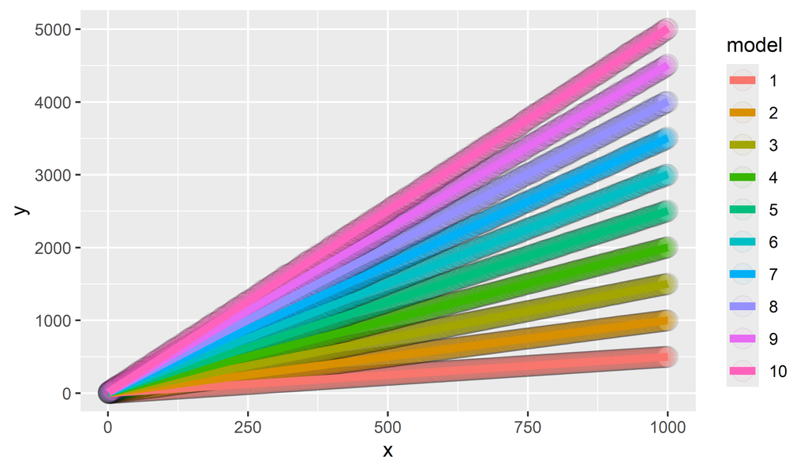

Figure 1: Linear model fits from the 10 models run.

```r
library(ggplot2)
input_data %>%
ggplot() +
geom_point(aes(x=x,y=y,fill=model),alpha=0.05,size=5,shape=21) +
geom_line(data=output_data,aes(x=x,y=pred_y,color=model),linewidth=2)
```

Back to top